# Italy COVID Forecast

Scott Bentrup

3/11/2020

## Problem and Data Import

COVID-19 is a virus currently spreading around the world. Italy has been the hot spot for the virus in Europe. Italian officials have published data online, refreshed each day, with the number of infections. I will attempt to forecast the total number of infections in Italy using this data in R. This data should be used for illustration only. No one should make any policy decisions based on this analysis. This project is for informaiton and my own personal learning only. Data is imported from https://raw.githubusercontent.com/pcm-dpc/COVID-19/master/dati-andamento-nazionale/dpc-covid19-ita-andamento-nazionale.csv.

# Import relevant libraries and data

I import the following libraries: library(data.table) library(forecast) library(tidyverse) library(dygraphs) library(lubridate) library(zoo) library(RColorBrewer)

```
##                   data stato ricoverati_con_sintomi terapia_intensiva
## 1: 2020-02-24 18:00:00   ITA                    101                26
## 2: 2020-02-25 18:00:00   ITA                    114                35
## 3: 2020-02-26 18:00:00   ITA                    128                36
## 4: 2020-02-27 18:00:00   ITA                    248                56
## 5: 2020-02-28 18:00:00   ITA                    345                64
## 6: 2020-02-29 18:00:00   ITA                    401               105
##    totale_ospedalizzati isolamento_domiciliare totale_attualmente_positivi
## 1:                  127                     94                         221
## 2:                  150                    162                         311
## 3:                  164                    221                         385
## 4:                  304                    284                         588
## 5:                  409                    412                         821
## 6:                  506                    543                        1049
##    nuovi_attualmente_positivi dimessi_guariti deceduti totale_casi tamponi
## 1:                        221               1        7         229    4324
## 2:                         90               1       10         322    8623
## 3:                         74               3       12         400    9587
## 4:                        203              45       17         650   12014
## 5:                        233              46       21         888   15695
## 6:                        228              50       29        1128   18661
```

In this data, “data” refers to the date and “totale_casi” is total cases. Since I do not speak Italian (at least, not well enough; Duolingo hasn’t gotten me far enough!) I cannot evaluate the other columns.

```
##      data              stato           ricoverati_con_sintomi terapia_intensiva
##  Length:17          Length:17          Min.   : 101           Min.   :  26.0
##  Class :character   Class :character   1st Qu.: 345           1st Qu.:  64.0
##  Mode  :character   Mode  :character   Median :1034           Median : 229.0
##                                        Mean   :1805           Mean   : 342.4
##                                        3rd Qu.:2651           3rd Qu.: 567.0
##                                        Max.   :5838           Max.   :1028.0
##  totale_ospedalizzati isolamento_domiciliare totale_attualmente_positivi
##  Min.   : 127         Min.   :  94           Min.   :  221
##  1st Qu.: 409         1st Qu.: 412           1st Qu.:  821
##  Median :1263         Median :1000           Median : 2263
##  Mean   :2147         Mean   :1235           Mean   : 3383
##  3rd Qu.:3218         3rd Qu.:1843           3rd Qu.: 5061
##  Max.   :6866         Max.   :3724           Max.   :10590
##  nuovi_attualmente_positivi dimessi_guariti     deceduti      totale_casi
##  Min.   :  74.0             Min.   :   1.0   Min.   :  7.0   Min.   :  229
##  1st Qu.: 228.0             1st Qu.:  46.0   1st Qu.: 21.0   1st Qu.:  888
##  Median : 443.0             Median : 160.0   Median : 79.0   Median : 2502
##  Mean   : 622.9             Mean   : 337.4   Mean   :190.2   Mean   : 3910
##  3rd Qu.: 620.0             3rd Qu.: 589.0   3rd Qu.:233.0   3rd Qu.: 5883
##  Max.   :2076.0             Max.   :1045.0   Max.   :827.0   Max.   :12462
##     tamponi
##  Min.   : 4324
##  1st Qu.:15695
##  Median :25856
##  Mean   :30443
##  3rd Qu.:42062
##  Max.   :73154
```

Since the data contains no missing values, we can continue with the analysis.

## Prepare the data and visualize the time series

I convert the data from character to time series using lubridate. Data is converted into a time series and visualized with dygraph. Graph is intentionally simple.

[interactive chart not shown]

## Generate an ARIMA model

```
##
##  ARIMA(0,2,0)                    : 228.3614
##  ARIMA(0,2,1)                    : 228.2352
##  ARIMA(0,2,2)                    : 225.841
##  ARIMA(0,2,3)                    : Inf
##  ARIMA(0,2,4)                    : Inf
##  ARIMA(0,2,5)                    : Inf
##  ARIMA(1,2,0)                    : 225.2624
##  ARIMA(1,2,1)                    : Inf
##  ARIMA(1,2,2)                    : 229.3415
##  ARIMA(1,2,3)                    : Inf
##  ARIMA(1,2,4)                    : Inf
##  ARIMA(2,2,0)                    : Inf
##  ARIMA(2,2,1)                    : Inf
##  ARIMA(2,2,2)                    : Inf
##  ARIMA(2,2,3)                    : 239.6829
##  ARIMA(3,2,0)                    : Inf
##  ARIMA(3,2,1)                    : 233.6654
##  ARIMA(3,2,2)                    : 239.2698
##  ARIMA(4,2,0)                    : Inf
##  ARIMA(4,2,1)                    : 238.602
##  ARIMA(5,2,0)                    : Inf
##
##
##
##  Best model: ARIMA(1,2,0)
```

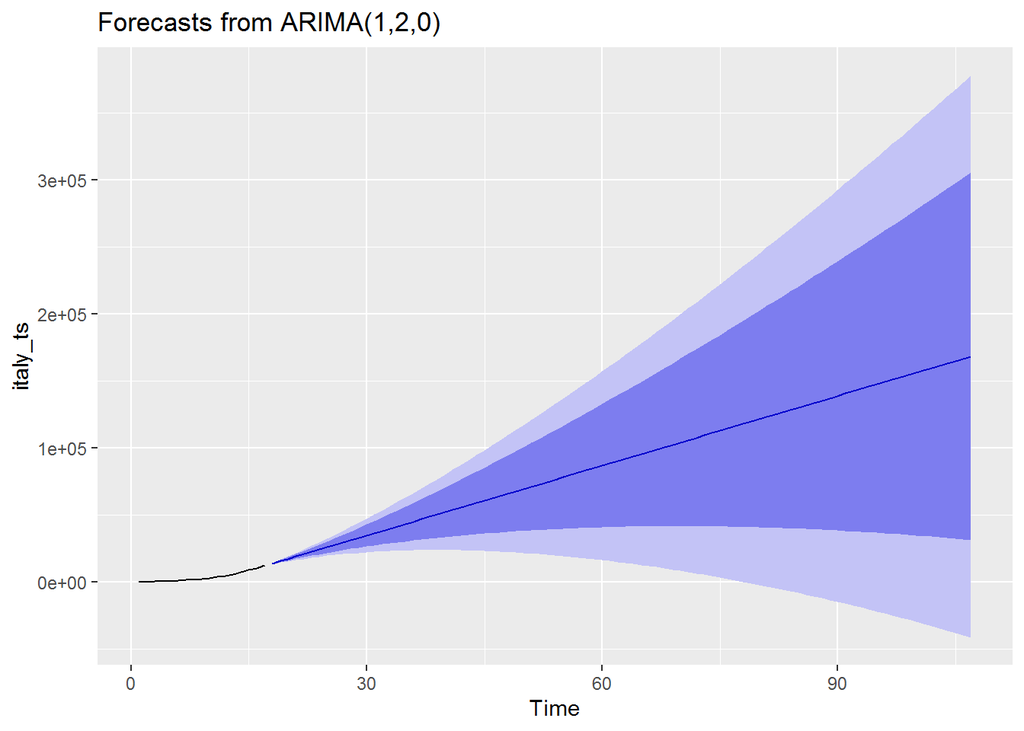

## Exponential smoothing model

Since the ARIMA model output seems to be a linear model it is not the ideal model. Next, I will try exponential smoothing using the ets() function with damping. This is because we know that at some point the number of cases will level or decrease. I also forecast this 90 days ahead and plot the results.

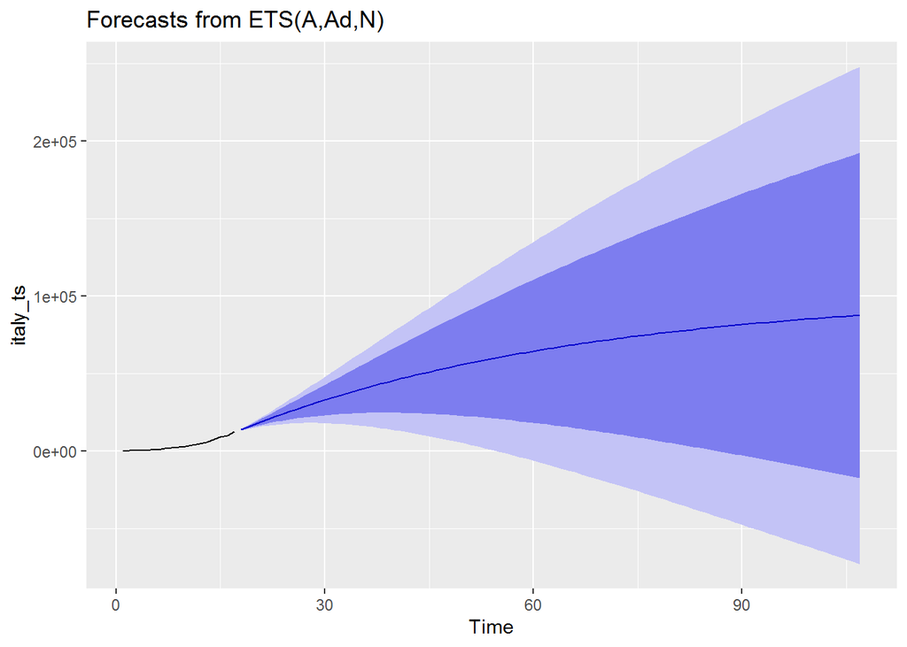

The ETS model seems like a better choice than the ARIMA model. I will now combine them and compare the two results in dygraph. This requires that we combine the time series forecasts into a data.frame then convert to a zoo format. I also add dates starting at the original end date + 1 and extend the date sequence 90 days

[interactive chart not shown]

# Discussion

# Conclusion

I hope this analysis is wrong and that the number of COVID-19 cases drops, rather than increases. I hope that if either of these models are in any way correct it is the ETS model, showing the lower number of cases. And above all else, I hope no one plans or makes any decisions on how to treat the COVID-19 outbreak based on these results.

R code is available upon request.